# Lab 03 - "Simulating Computational Infrastructure for Real-Time AI"

## - Lab Name: AI_Simulation_Infrastructure

# Part 1: Setting up the Environment:

In Part 1, I used the Jupyter Notebook to set up my environment.

# Part 2: Simulating Data Processing:

### 1. Import the necessary libraries:

```python
import numpy as np
import pandas as pd
import matplotlib.pyplot as plt
import psutil
import time
```

### 2. Create a function to generate random sensor data:

```python
def generate_sensor_data(num_sensors, num_readings): return np.random.rand(num_sensors, num_readings)
```

### 3. Create a data processing function:

```python
def process_data(data): return np.mean(data, axis=1)
```

### 4. Simulate real-time data processing:

```python
num_sensors = 1000
num_readings = 100
num_iterations = 50
processing_times = []

for _ in range(num_iterations):
    data = generate_sensor_data(num_sensors, num_readings)
    start_time = time.time()
    processed_data = process_data(data)
    end_time = time.time()
    processing_times.append(end_time - start_time)
```

### 5. Visualize the processing times:

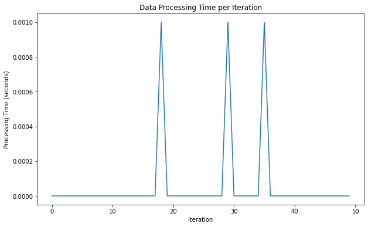

```python
plt.figure(figsize=(10, 6))
plt.plot(processing_times)
plt.title('Data Processing Time per Iteration')
plt.xlabel('Iteration')
plt.ylabel('Processing Time (seconds)')
plt.show()
```

# Part 3: Simulating Hardware Components

### 1. Create functions to simulate CPU and memory usage:

```python
def simulate_cpu_usage(duration):
    """Simulates CPU usage by running an empty loop for the specified duration (in seconds)."""
    start_time = time.time()
    while time.time() - start_time < duration:
        pass  # CPU busy-waiting

def simulate_memory_usage(size_mb):
    """Simulates memory usage by allocating a string of a specified size (in megabytes)."""
    return ' ' * (size_mb * 1024 * 1024)  # Returns a string that takes up the specified MB in memory
```

### 2. Monitor and plot CPU usage over time as you simulate CPU activity:

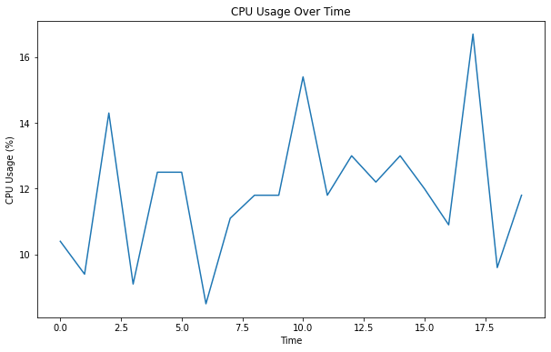

```python
cpu_usage = []

# Simulate CPU usage and collect data for 20 iterations
for _ in range(20):
    simulate_cpu_usage(0.1)  # Simulates 0.1 second of CPU usage
    cpu_usage.append(psutil.cpu_percent())  # Get the current CPU usage percentage

# Plot the CPU usage over time
plt.figure(figsize=(10, 6))
plt.plot(cpu_usage)
plt.title('CPU Usage Over Time')
plt.xlabel('Time')
plt.ylabel('CPU Usage (%)')
plt.show()
```

### 3. Monitor and plot memory usage as the program allocates increasing memory:

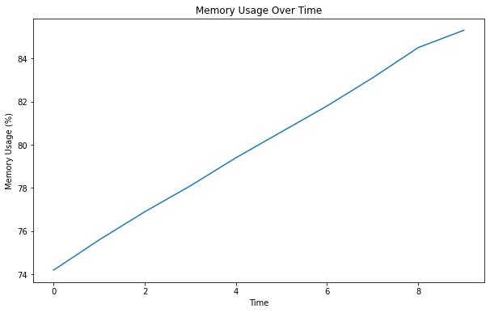

```python
memory_usage = []

# Simulate memory allocation in 100MB increments for 10 iterations
for i in range(10):
    _ = simulate_memory_usage(100 * i)  # Allocate memory, increasing by 100MB each iteration
    memory_usage.append(psutil.virtual_memory().percent)  # Record the percentage of memory usage

# Plot the memory usage over time
plt.figure(figsize=(10, 6))
plt.plot(memory_usage)
plt.title('Memory Usage Over Time')
plt.xlabel('Time')
plt.ylabel('Memory Usage (%)')
plt.show()
```

# Part 4: Reflection and Analysis

### 1. Observations on Processing Times:

#### Patterns:

During the lab, I noticed that processing times varied between iterations. This fluctuation could be attributed to factors like the random nature of the sensor data and possible interference from other system processes. These variations suggest that ensuring consistent processing times is crucial for real-time AI simulations, as significant fluctuations could impact the reliability of the system.

#### Memory Usage:

As more memory was allocated, memory usage increased as expected. High memory usage could potentially lead to problems such as swapping or out-of-memory errors, which can disrupt real-time performance. Efficient memory management is essential to avoid these issues.

### 3. Analysis of Optimizations and Hardware Improvements:

#### Optimizations:

To improve efficiency, I would consider implementing parallel processing and optimizing algorithms to reduce processing time and resource demands. These changes could help in managing fluctuations and enhancing performance.

#### Hardware Upgrades:

Upgrading to faster processors, increasing RAM, and using SSDs could significantly boost performance and support real-time AI applications more effectively, ensuring smoother and more reliable operations.

These observations and analyses suggest that while the current setup provides valuable insights, optimizations and hardware improvements could enhance performance for real-time AI simulations.